# Individual Tasks NMST539

Zhang Shuo

2/20/2022

## Task 1

### Data set annualpopu was selected

The data set shows yearly average population rates for the old federal states in Germany (given in 1000 inhabitants)

### First, have a brief look at this data set.

```r
library(SMSdata)
data(annualpopu)
summary(annualpopu)
```

```
##       Year       Inhabitants      Unemployed
##  Min.   :1960   Min.   :55433   Min.   : 147.0
##  1st Qu.:1969   1st Qu.:60213   1st Qu.: 252.2
##  Median :1978   Median :61412   Median :1045.0
##  Mean   :1978   Mean   :61381   Mean   :1232.8
##  3rd Qu.:1988   3rd Qu.:62034   3rd Qu.:2228.8
##  Max.   :1997   Max.   :66648   Max.   :3021.0
```

```r
str(annualpopu)
```

```
## 'data.frame':    38 obs. of  3 variables:
##  $ Year       : int  1960 1961 1962 1963 1964 1965 1966 1967 1968 1969 ...
##  $ Inhabitants: int  55433 56158 56837 57389 57971 58619 59148 59268 59500 60067 ...
##  $ Unemployed : int  271 181 155 186 169 147 161 459 323 179 ...
```

### Then there are Chernoff’s Faces

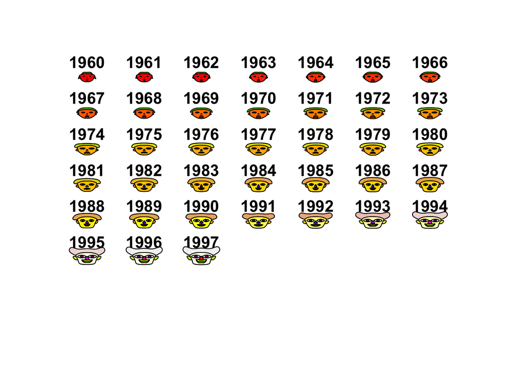

```
## effect of variables:
##  modified item       Var
##  "height of face   " "Year"
##  "width of face    " "Inhabitants"
##  "structure of face" "Unemployed"
##  "height of mouth  " "Year"
##  "width of mouth   " "Inhabitants"
##  "smiling          " "Unemployed"
##  "height of eyes   " "Year"
##  "width of eyes    " "Inhabitants"
##  "height of hair   " "Unemployed"
##  "width of hair   "  "Year"
##  "style of hair   "  "Inhabitants"
##  "height of nose  "  "Unemployed"
##  "width of nose   "  "Year"
##  "width of ear    "  "Inhabitants"
##  "height of ear   "  "Unemployed"
```

```r
library(aplpack)
faces(annualpopu)
```

As you can see from the faces on the above, the amount of data for both variables increased with the year. An increase in face width, for example, shows an increase in the total number of inhabitants, which also reflects general demographic trends in Germany’s old federal states.

### At last a Two-dimensional kernel density estimation

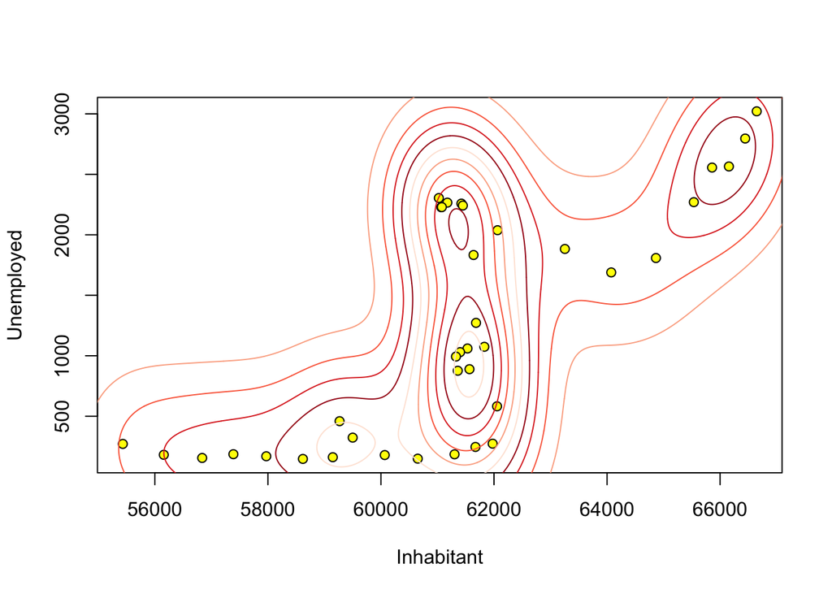

```r
library(MASS)
library("RColorBrewer")
colors <- brewer.pal(5, "Reds")
z <- kde2d(annualpopu$Inhabitants,annualpopu$Unemployed,n=500, lims = c(50000,70000,0,3500))
plot(annualpopu$Inhabitants,annualpopu$Unemployed, xlab="Inhabitant", ylab="Unemployed", pch=21, bg = "yellow")
contour(z, drawlabels=FALSE, nlevels=10, col=colors, add=TRUE)
```

The figure above shows the density of the data and from which we can also conclude that in the early stage, the total number of inhabitants grew rapidly, and in the mid-term, the number of unemployed experienced rapid growth.

## Task 2

### Theoretical example

the random vector $\left(X_{i}, Y_{i}\right)^{T}$follows the uniform distribution with density
$$f(x, y)=c \cdot 1_{[(x, y) \in M]} \text { ， } M=\left\{(x, y) \in \mathbb{R}^{2} ; 0<x<y<1\right\}$$
and M is a 2 dimensional Lebesgue measurable set, from which we can get $c=2$ and also get

1.the density function
$$f(x, y)=2 \cdot 1_{[(x, y) \in M]}$$
2.marginal density
$$f_{X}(x)=\int_{x}^{1} f(x, y) d y=2(1-x),x \in(0,1)$$
3.marginal density
$$f_{Y}(y)=\int_{0}^{y} f(x, y) d x=2 y ,y \in(0,1)$$
4.not independent,for
$$f_{X}(x)f_{Y}(y)=4(1-x)y\neq2,(x, y) \in M$$
$$E X_{i}=\int_{0}^{1} 2 x(1-x) d x=\frac{1}{3}$$
$$E Y_{i}=\int_{0}^{1} 2 y^{2} d y=\frac{2}{3}$$

$$\operatorname{Var}\left(X_{i}\right)=
\mathrm{E}\left(X_{i}^{2}\right)-\left(\mathrm{E} X_{i}\right)^{2}=\int_{0}^{1} 2 x^{2}(1-x) d x-\frac{1}{3^2}=\frac{1}{18}$$

$$\operatorname{Var}\left( Y_{i}\right)=
\mathrm{E}\left(Y_{i}^{2}\right)-\left(\mathrm{E} Y_{i}\right)^{2}=\int_{0}^{1} 2 y^{3} d y-\frac{2^2}{3^2}=\frac{1}{18}$$
$$\operatorname{cov}\left(X_{i}, Y_{i}\right)=\mathrm{E}\left(X_{i} \ Y_{i}\right)-\mathrm{E} X_{i} \mathrm{E} Y_{i}=\int_{0} ^{1}\int_{0}^{y} xy f(x, y) d x d y-\frac{2}{3^2} =\frac{1}{36}$$
$$\operatorname{Var}\left(X_{i}, Y_{i}\right)=\left(\begin{array}{cc}
\frac{1}{18} & \frac{1}{36} \\
\frac{1}{36} & \frac{1}{18}
\end{array}\right)$$

### Practical example

At first, calculate the CDF of x.
$$F_{X}=\int_{-\infty}^{x} 2(1-u) 1_{u \in(0,1)} d u= \begin{cases}0 & \text { if } x<0 \\ 2 x-x^{2} & \text { if } x \in(0,1) \\ 1 & \text { if } x>1\end{cases}$$
and the corresponding quantile function is

$$F_{X}^{-1}(z^*)=1-\sqrt{1-z^*} \quad z^* \in(0,1)$$
$$F_{Y}=\int_{-\infty}^{y} 2u 1_{u \in(0,1)} d u= \begin{cases}0 & \text { if } y<0 \\ y^{2} & \text { if } y \in(0,1) \\ 1 & \text { if } y>1\end{cases}$$
then calculate both conditional CDF of x and the corresponding quantile function
$$f_{y\mid x}= \frac{f_{x, y}(x,y)}{f_{ x}(x)}=\frac{1}{1-x}\quad x \in(0,1)$$
$$F_{Y \mid X}=\int_{-\infty}^{y}\frac{1}{1-x}dy= \begin{cases}0 & \text { if } y<x \\ \frac{y-x}{1-x} & \text { if } y \in(x,1) \\ 1 & \text { if } y>1\end{cases}$$

$$F_{Y \mid X}^{-1}(z)=z(1-x)+x, \quad z \in(0,1)$$

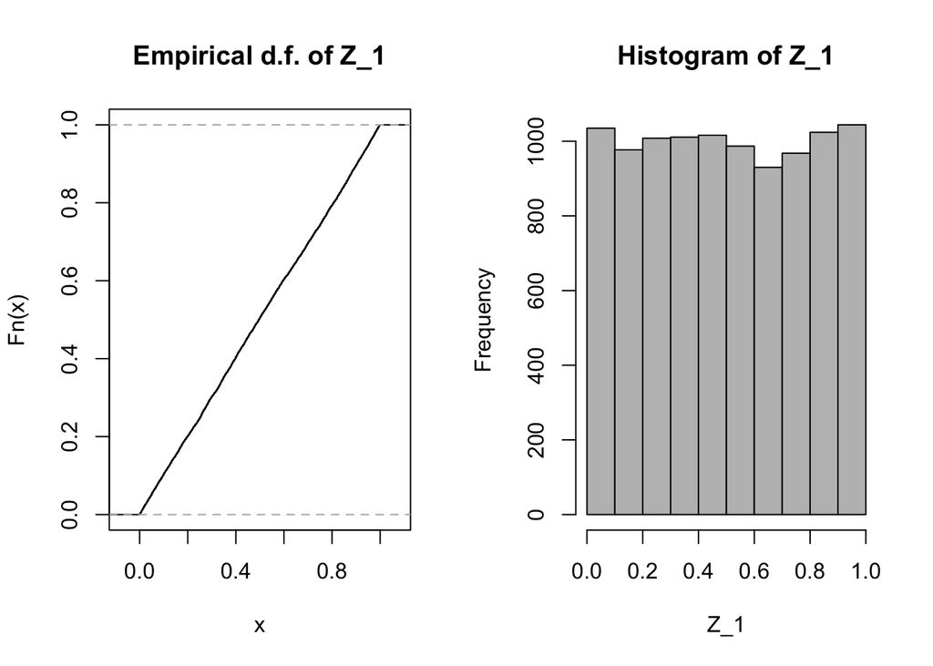

```r
n <- 10000
set.seed(1)

Z_1 <- runif(n)
par(mfrow = c(1,2))
plot(ecdf(Z_1), main = "Empirical d.f. of Z_1")
hist(Z_1, col = "gray", breaks = ceiling(10))
```

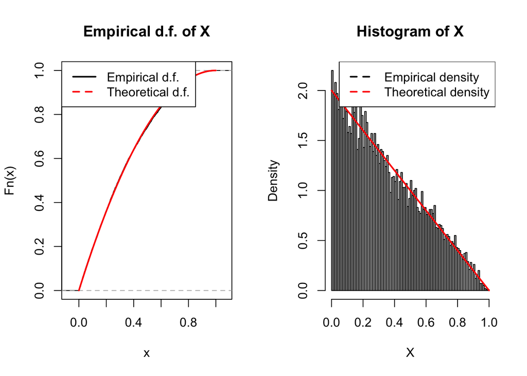

```r
X <- 1-sqrt(1-Z_1)
xSeq <- seq(0,1, length = 10000)
par(mfrow = c(1,2))
plot(ecdf(X), main = "Empirical d.f. of X")
lines((2*xSeq-xSeq^2) ~ xSeq, col = "red", lty = 2, lwd = 2)
legend("topleft", legend = c("Empirical d.f.", "Theoretical d.f."), col = c("black", "red"), lty = c(1,2), lwd =c (2,2))
hist(X, freq = F, col = "gray", breaks = ceiling(sqrt(n)))
lines((2-2*xSeq) ~ xSeq, col = "red", lty = 2, lwd = 2)
legend("topright", legend = c("Empirical density", "Theoretical density"), col = c("black", "red"), lty = c(2,2), lwd = c(2,2))
```

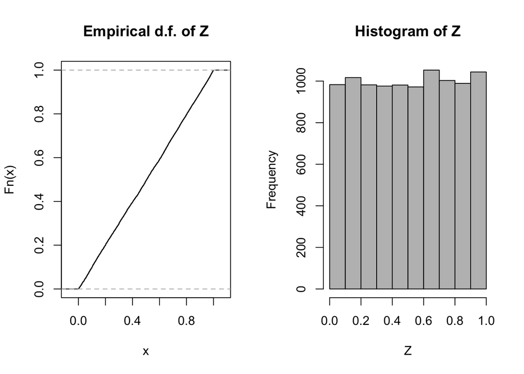

```r
n <- 10000
set.seed(2)

Z <- runif(n)
par(mfrow = c(1,2))
plot(ecdf(Z), main = "Empirical d.f. of Z")
hist(Z, col = "gray", breaks = ceiling(10))
```

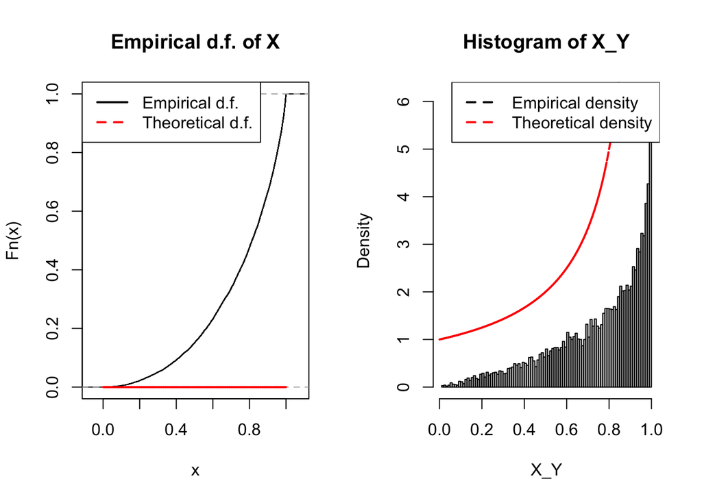

```r
X_Y <- Z*(1-Z_1)+Z_1
ySeq <- seq(0,1, length = 10000)
par(mfrow = c(1,2))
plot(ecdf(X_Y), main = "Empirical d.f. of X")
lines((ySeq-xSeq)/(1-xSeq) ~ ySeq, col = "red", lty = 2, lwd = 2)
legend("topleft", legend = c("Empirical d.f.", "Theoretical d.f."), col = c("black", "red"), lty = c(1,2), lwd =c (2,2))
hist(X_Y, freq = F, col = "gray", breaks = ceiling(sqrt(n)))
lines(1/(1-xSeq) ~ ySeq, col = "red", lty = 2, lwd = 2)
legend("topright", legend = c("Empirical density", "Theoretical density"), col = c("black", "red"), lty = c(2,2), lwd = c(2,2))
```

sample means and the sample variance-covariance matrix
$$\bar{X}_{n}$$

```r
mean(1-sqrt(1-Z_1))
```

```
## [1] 0.3343354
```